# Input Data Verification & Phenology Module

Verifying Data Inputs and Generating Continuous Daily Crop Coefficient (Kc) Curves for the Blue Water Potential Toolkit

Authors

Rutuja Chitra-Tarak (Code)

Charlotte Hemingway (Data and Original Calculations)

Laurent Ruiz (Data and Original Calculations)

**Note to Users**: The primary requirement to run the main Blue Water Potential Toolkit (`02_Blue-Water.qmd`) is the set of standardized static CSV inputs, combined with the dynamic phenology curves generated by this script.

### 0.0.1 🗂️ Overview & Data Summary

This script processes, visualizes, and expands the input data required by the hydrological model. The data is organized into up to 10 standardized datasets across three analytical scales:

**Scale 1: Blue Water Potential for Cropping Systems**

1. **Model Parameters (`01_model_parameters.csv`)**: The master configuration file defines global baseline assumptions, including seasonal bare-soil evaporation coefficients (kc_dry_season, kc_kharip), the calendar day to switch between them (doy_switch), the starting soil moisture fraction (sm_init), and the soil_input routing switch—–which dictates whether the model should use raw Precipitation (P) or calculate surface runoff to use Effective Precipitation (Peff).
2. **Precipitation (`02_precipitation.csv`)**: Multi-year daily precipitation forcings.
3. **Reference ET0 (`03_et0.csv`)**: Multi-year daily reference evapotranspiration forcings.
4. **Soil Properties (`04_soil.parameters.csv`)**: Water Holding Capacity (WHC) and Readily Available Water (RAW).
5. **Crop Parameters (`05_crop.parameters.csv`)**: Rooting depths and whether the crop is irrigated or rainfed.
6. **FAO Kc Curve Parameters (`06_fao_kc_curve_parameters_table.csv`)**: Sowing date, phenological phase duration, and respective crop coefficients (Kc) according to the FAO-56 method (Allen et al., 1998).
7. **Monthly Step Kc Parameters (`07_step_kc_curve_parameters_table.csv`)**: *(Optional)* Monthly crop coefficients for specific applications, such as fruit trees.
8. **Cropping Systems (`08_crop.systems.csv`)**: Crop rotation definitions at the plot scale.

**Scale 2: Blue Water Potential for Production Systems**

9. **Area by Production System (`09_crop_system_area_by_production_system.csv`)**: Aggregation of grazed and cropped area (ha) for each farming system.

**Scale 3: Blue Water Potential for Agrarian Systems**

10. **Farm Counts (`10_no_of_farmers_by_production_system.csv`)**: Total number of farmers belonging to each production system in a given village/micro-region.

*In Hemingway et al. (2026), this process was run for two agrarian systems, corresponding to two historical periods: the 1950s and 2022. The climate time series (1980-2018) was held constant to isolate the impact of land-use changes, while cropping systems, production systems, and agrarian systems were period-specific.*

### 0.0.2 🗂️ Data Architecture & Workflow

The Blue Water Potential Toolkit uses a strict, automated pipeline to separate user-provided data from model-generated data.

**1. `data/input/` (The User Interface)** This folder is the starting point of the toolkit. It holds all the static, standardized CSV files listed above. **If you are adapting this toolkit for your own study site, this is the only folder you need to populate.**

**2. `data/processed/` (The Phenology Module)** This folder is fully automated. When you render this script (`01_Prepare_Model_Input.qmd`), it reads the static parameters from `data/input/`, executes the mathematical rule-sets (FAO-56 segments, polynomial equations, grazing regrowth), and outputs the continuous daily Crop Coefficient ($K_c$) tables here. *Users do not need to manually edit files in this folder.*

### 0.0.3 📂 Directory Structure for this Script

The Blue Water Potential Toolkit serves two purposes: it can be used to reproduce the results presented in Hemingway et al. (2026), and it can be applied to new study sites. As the first step in the pipeline, this script is where both workflows begin.

- **Reproducing the Manuscript:** All clean inputs required to run this script are already provided in the `data/input/` directory.
- **Adapting for your own study site:** Place your clean data in the `data/input/` folder. The script will automatically generate the required folder structure for all derived processed outputs. To run this script, open the `.Rproj` and click “Render”.

```
project_root/
├── data/
│   ├── input/                       <- REQUIRED: Drop your 10 standardized CSVs here
│   │   ├── 01_model_parameters.csv
│   │   ├── 02_precipitation.csv
│   │   ├── 03_et0.csv
│   │   ├── 04_soil.parameters.csv
│   │   ├── 05_crop.parameters.csv
│   │   ├── 06_fao_kc_curve_parameters_table.csv
│   │   ├── 07_step_kc_curve_parameters_table.csv (optional)
│   │   ├── 08_crop.systems.csv
│   │   ├── 09_crop_system_area_by_production_system.csv
│   │   └── 10_no_of_farmers_by_production_system.csv
│   └── processed/                   <- AUTOMATED: Derived model requirements land here
│       └── supplementary/           <- Generated: Intermediary Kc tables
├── code/
│   ├── functions/                   <- Core toolkit mathematical dependencies
│   ├── 01_Prepare_Model_Inputs.qmd  <- (This file)
│   └── 01_Prepare_Model_Inputs.html <- Generated: HTML Report created by rendering this script
└── Blue-Water.Rproj                 <- Required: RStudio Project file to render this script
```

# 1 Model Configuration Parameters

Read the master configuration file.

Hydrological Parameters

| Parameter | Value | Category |
| --- | --- | --- |
| kc_dry_season | 0.005 | Crop coefficient for bare soil during the dry season Expected: Numeric |
| kc_kharip | 0.2 | Crop coefficient for bare soil during the Kharip (monsoon) season Expected: Numeric |
| doy_switch | 120 | Day of Year (DOY) to switch between dry season and Kharip evaporation rules Expected: Numeric |
| sm_init | 0.5 | Initial soil moisture fraction at the start of the simulation (0 to 1) Expected: Numeric |
| soil_input | P | Precipitation routing switch: ‘P’ uses raw rainfall, ‘Peff’ calculates surface runoff Expected: Character string (‘P’ or ‘Peff’) |

# 2 Climatic Data (Forcing Variables)

The water balance model requires continuous, daily forcing variables. Here, we read the required daily Precipitation (P) and Reference Evapotranspiration (ET0).

```r
precip <- data.table::fread(here::here("data/input/02_precipitation.csv")) %>% dplyr::as_tibble()
et0.daily <- data.table::fread(here::here("data/input/03_et0.csv")) %>% dplyr::as_tibble()
et0.daily <- et0.daily %>%
  dplyr::mutate(et0 = base::round(et0, 3))

base::stopifnot(
  "Error: Precipitation contains missing values (NA)." = !base::any(base::is.na(precip$p)),
  "Error: ET0 contains missing values (NA)." = !base::any(base::is.na(et0.daily$et0))
)
# Only for figure plotting
climate_summary <- data.table::fread(here::here("data/input/supplementary/01_monthly_climatology_for_figure.csv")) %>% dplyr::as_tibble()
```

#### 2.0.0.1 Precipitation

Preview: Precipitation Data Sample

| date Sequential dates **Expected:** Date (YYYY-MM-DD) | p Daily Precipitation (mm ≥ 0) **Expected:** Numeric |
| --- | --- |
| 1980-01-01 | 0 |
| 1980-01-02 | 0 |
| 1980-01-03 | 0 |
| 1980-01-04 | 0 |
| 1980-01-05 | 0 |

#### 2.0.0.2 Reference Evapotranspiration (ET0)

Preview: ET0 Data Sample

| date Sequential dates **Expected:** Date (YYYY-MM-DD) | ET0 Daily Reference Evapotranspiration (mm ≥ 0) **Expected:** Numeric |
| --- | --- |
| 1980-01-01 | 3.799 |
| 1980-01-02 | 4.036 |
| 1980-01-03 | 4.315 |
| 1980-01-04 | 4.125 |
| 1980-01-05 | 4.576 |

#### 2.0.0.3 Monthly Climatology (Only for plotting figure)

Study Site Climatology

| Month | Temperature_avg | Temperature_sd | Rainfall_avg | Rainfall_sd | ET0_avg | ET0_sd |
| --- | --- | --- | --- | --- | --- | --- |
| 1 | 23.8 | 0.7 | 1.3 | 3.9 | 135.0 | 8.5 |
| 2 | 26.4 | 0.8 | 0.4 | 1.1 | 148.8 | 9.1 |
| 3 | 29.8 | 0.7 | 7.2 | 17.2 | 189.0 | 8.9 |
| 4 | 32.5 | 0.7 | 13.1 | 17.2 | 195.4 | 9.2 |
| 5 | 32.6 | 0.9 | 48.3 | 37.3 | 207.0 | 16.3 |
| 6 | 30.0 | 0.7 | 59.7 | 49.3 | 170.1 | 14.9 |
| 7 | 28.7 | 0.7 | 77.8 | 89.7 | 154.0 | 14.0 |
| 8 | 28.2 | 0.7 | 89.5 | 84.2 | 144.6 | 13.7 |
| 9 | 27.9 | 0.9 | 128.4 | 83.0 | 136.8 | 13.4 |
| 10 | 27.1 | 0.8 | 83.8 | 57.2 | 124.6 | 11.3 |
| 11 | 24.9 | 0.8 | 32.1 | 45.2 | 110.6 | 9.8 |
| 12 | 23.4 | 0.8 | 6.8 | 11.0 | 115.9 | 9.9 |

# 3 Soil Parameters

The hydrological model requires specific soil properties: Water Holding Capacity (WHC) and Readily Available Water (RAW).

```r
soil.param <- data.table::fread(here::here("data/input/04_soil.parameters.csv")) %>% dplyr::as_tibble()
```

#### 3.0.0.1 Soil Parameters Table

Soil Parameter Table

| soil Identifier code **Expected:** Numeric or Character | soil.type Descriptive classification **Expected:** Character | whc.mmpercm WHC (mm water / cm soil) **Expected:** Numeric | raw Readily Available Water threshold **Expected:** Numeric | CN SCS Curve Number **Expected:** Numeric | lambda Initial Abstraction ratio **Expected:** Numeric |
| --- | --- | --- | --- | --- | --- |
| 1 | RED LOAMY | 1.7 | 1 | 85 | 0.3 |
| 2 | GREY CLAYEY | 1.8 | 1 | 85 | 0.2 |

# 4 Crop Characteristics

## 4.1 Rooting Depth and Irrigated/Rainfed

```r
crop.param <- data.table::fread(here::here("data/input/05_crop.parameters.csv")) %>% dplyr::as_tibble()
```

#### 4.1.0.1 Crop Rooting Depth and Irrigated/Rainfed

Crop Rooting Depth and Crop Irrigated/Rainfed Table

| crop Internal name for a Crop or Crop-Year (e.g., Banana 1) **Expected:** Character | irrigation ‘irrigated’ or ‘rainfed’ **Expected:** Character (Strict match) | rooting_depth_cm Max effective root depth **Expected:** Numeric |
| --- | --- | --- |
| No Crop | rainfed | 0 |
| Rice Long | irrigated | 50 |
| Rice Short Monsoon | irrigated | 50 |
| Rice Short Summer | irrigated | 50 |
| Groundnut Summer | irrigated | 70 |
| Banana 2 | irrigated | 65 |
| Banana 1 Beg | irrigated | 65 |
| Banana 1 Next | irrigated | 65 |
| Pulse | rainfed | 65 |
| Tomato Summer | irrigated | 70 |
| Groundnut Monsoon | rainfed | 70 |
| Ragi | irrigated | 90 |
| Millet | rainfed | 90 |
| Sweet Lime | irrigated | 140 |
| Grapes | irrigated | 150 |
| Napier | irrigated | 150 |
| Napier Short | irrigated | 150 |
| Pomegranate | irrigated | 150 |
| Horsegram | rainfed | 65 |
| Okra Summer | irrigated | 70 |
| Okra Winter | irrigated | 70 |
| Tomato Winter | irrigated | 70 |
| Grasslands | rainfed | 30 |
| Grazed Thrice | rainfed | 30 |
| Grazed 1 Aug | rainfed | 30 |
| Grazed 1 Sept | rainfed | 30 |
| Grazed 1 Oct | rainfed | 30 |
| Grazed 1 Nov | rainfed | 30 |

## 4.2 Crop Coefficient (Kc) Curves

Our framework dynamically generates daily Kc curves over a calendar year from the input parameters. As described in the manuscript, daily Kc values are computed based on the FAO method for most crops, monthly step functions for some fruit trees, or polynomial equations for groundnut, or linear regrowth rules for grasslands. Some crops such as banana can span multiple years, in which case we define a crop coefficient curve of each year independently.

```r
fao_kc_raw       <- data.table::fread(here::here("data/input/06_fao_kc_curve_parameters_table.csv")) %>% dplyr::as_tibble()
fruit_kc_raw   <- data.table::fread(here::here("data/input/07_step_kc_curve_parameters_table.csv")) %>% dplyr::as_tibble()
```

#### 4.2.0.1 FAO Segmented Parameters

Dictionary of FAO-56 Curve Variables

| Variable | Description | Expected_Type |
| --- | --- | --- |
| Sowing | Day of year (1-366) when the crop is sown or planted | Numeric (1-366) |
| Kc_ini | Crop coefficient (Kc) during the initial growth stage | Numeric |
| Ini_duration | Duration of the initial growth stage in days | Numeric |
| End of ini | Day of year when the initial growth stage ends | Numeric (1-366) |
| Dev_duration | Duration of the crop development stage in days | Numeric |
| End of Dev | Day of year when the crop development stage ends | Numeric (1-366) |
| Kc_mid | Crop coefficient (Kc) during the mid-season stage | Numeric |
| Mid_duration | Duration of the mid-season stage in days | Numeric |
| End of Mid | Day of year when the mid-season stage ends | Numeric (1-366) |
| Kc_end | Crop coefficient (Kc) at the end of the late-season stage (harvest) | Numeric |
| End_duration | Duration of the late-season stage in days | Numeric |
| Harvest | Day of year when the crop is harvested | Numeric (1-366) |

FAO Segmented Parameters Data Preview

| var | Ragi | Millet | Pulse | Rice_Short_Monsoon | Rice_Short_Summer | Okra_summer | Okra_winter | Tomato_summer | Tomato_winter | Grasslands | Horsegram | Rice_Long | Banana_2 | Grapes | Banana_1_beg | Banana_1_next |
| --- | --- | --- | --- | --- | --- | --- | --- | --- | --- | --- | --- | --- | --- | --- | --- | --- |
| Sowing | 122.0 | 197.0 | 197.0 | 197.00 | 32.00 | 1.0 | 153.0 | 1.0 | 183.0 | 122.0 | 289.0 | 245.00 | 214 | 92.0 | 340 | 1 |
| Kc_ini | 0.3 | 0.3 | 0.4 | 1.15 | 1.15 | 0.2 | 0.2 | 0.6 | 0.6 | 0.2 | 0.4 | 1.15 | 1 | 0.3 | 1 | 1 |
| Ini_duration | 15.0 | 15.0 | 15.0 | 30.00 | 30.00 | 10.0 | 10.0 | 30.0 | 30.0 | 30.0 | 15.0 | 30.00 | 120 | 20.0 | 120 | 95 |
| End of ini | 137.0 | 212.0 | 212.0 | 227.00 | 62.00 | 11.0 | 163.0 | 31.0 | 213.0 | 152.0 | 304.0 | 275.00 | 334 | 112.0 | 460 | 96 |
| Dev_duration | 25.0 | 25.0 | 25.0 | 30.00 | 30.00 | 31.0 | 31.0 | 40.0 | 40.0 | 120.0 | 25.0 | 30.00 | 60 | 50.0 | 90 | 90 |

#### 4.2.0.2 Fruit Tree Parameters

Fruit Tree Parameters

| Month | Pomegranate | Sweet lime |
| --- | --- | --- |
| 1 | 1.18 | 1.05 |
| 2 | 1.09 | 1.17 |
| 3 | 1.00 | 1.10 |
| 4 | 0.88 | 1.00 |
| 5 | 0.83 | 0.87 |
| 6 | 0.87 | 0.77 |
| 7 | 0.89 | 0.76 |
| 8 | 0.15 | 0.69 |
| 9 | 0.30 | 0.63 |
| 10 | 0.59 | 0.66 |
| 11 | 0.92 | 0.74 |
| 12 | 1.16 | 0.88 |

We pass the input Kc parameters through mathematical functions. This includes standard FAO-56 segmented curves for standard crops, derived 4th-order polynomial equations for continuous rapid growth crops like Groundnuts, and complex daily linear regrowth rates for pastures and harvested grasses.

### 4.2.1 Standard FAO-56 Segmented Curves

Generates the classic 4-stage linear growth curves for standard crops.

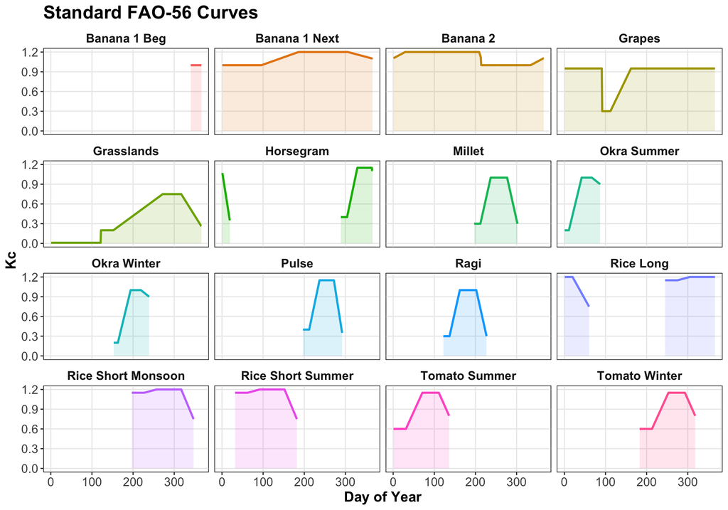

Standard FAO-56 segmented curves based on major crop calendar events such as sowing and harvesting dates, and crop development duration.

```r
fao_kc_raw.long <- fao_kc_raw %>%
  tidyr::pivot_longer(cols = -1, names_to = "crop") %>%
  dplyr::mutate(crop = stringr::str_to_title(base::gsub("_|\\.", " ", crop, perl = TRUE)))

kc <- fao_kc_raw.long %>%
  base::subset(stringr::str_detect(var, stringr::regex("kc", ignore_case = TRUE))) %>%
  dplyr::rename(Kc = value, kc_var = var) %>%
  dplyr::mutate(Kc_var = dplyr::case_when(
    base::grepl("ini", kc_var, ignore.case = TRUE) ~ "Kc_ini",
    base::grepl("mid", kc_var, ignore.case = TRUE) ~ "Kc_mid",
    base::grepl("end", kc_var, ignore.case = TRUE) ~ "Kc_end",
    TRUE ~ kc_var
  ))

doy <- fao_kc_raw.long %>%
  base::subset(var %in% c("Sowing", "End of ini", "End of Dev", "End of Mid", "Harvest")) %>%
  dplyr::rename(doy = value, doy_var = var) %>%
  dplyr::mutate(doy = dplyr::if_else(doy == 365.00, 366.00, doy))

kc.doy.key <- base::data.frame(doy_var = c("Sowing", "End of ini", "End of Dev", "End of Mid", "Harvest"), kc_var = c("Kc_ini", "Kc_ini", "Kc_mid", "Kc_mid", "Kc_end"))

doy <- dplyr::left_join(doy, kc.doy.key, by = c("doy_var"))
kc.doy <- dplyr::left_join(doy, kc, by = c("kc_var", "crop")) %>%
  dplyr::arrange(crop, doy, Kc) %>%
  dplyr::mutate(doy = base::as.numeric(doy), Kc = base::as.numeric(Kc))

kc.doy.crops <- kc.doy %>%
  dplyr::select(crop, doy_var, doy, Kc) %>%
  dplyr::mutate(doy_var = base::factor(doy_var, levels = c("Sowing", "End of ini", "End of Dev", "End of Mid", "Harvest"))) %>%
  dplyr::arrange(crop, doy, doy_var)

kc_wide_build <- kc.doy.crops %>%
  tidyr::pivot_wider(names_from = doy_var, values_from = c(doy, Kc)) %>%
  dplyr::rename(
    Sow = doy_Sowing, E_ini = `doy_End of ini`, E_dev = `doy_End of Dev`,
    E_mid = `doy_End of Mid`, Harv = doy_Harvest,
    K_ini = Kc_Sowing, K_mid = `Kc_End of Dev`, K_end = Kc_Harvest
  )

kc_segmented_ls <- base::lapply(1:base::nrow(kc_wide_build), function(i) build_fao_curve(kc_wide_build[i, ]))
kc_segmented <- dplyr::bind_rows(kc_segmented_ls) %>%
  dplyr::mutate(crop = stringr::str_to_title(base::gsub("_", " ", crop, perl = TRUE)))

# Visual Check
ggplot2::ggplot(
  kc_segmented %>%
    # 1. Remove the baseline fallow periods entirely
    dplyr::filter(kc > 0) %>%
    dplyr::arrange(crop, doy) %>%
    dplyr::group_by(crop) %>%
    # 2. Flag contiguous growth phases whenever there is a jump in DOY
    dplyr::mutate(
      is_gap = doy - dplyr::lag(doy, default = dplyr::first(doy)) > 1,
      plot_group = base::paste(crop, base::cumsum(is_gap), sep = "_")
    ) %>%
    dplyr::ungroup(),

  # 3. Apply the dynamic group aesthetic!
  ggplot2::aes(x = doy, y = kc, color = crop, group = plot_group)
) +
  ggplot2::geom_area(ggplot2::aes(fill = crop), alpha = 0.15, show.legend = FALSE, na.rm = TRUE) +
  ggplot2::geom_line(linewidth = 1, na.rm = TRUE) +
  ggplot2::facet_wrap(~ crop) +
  theme_baseR +
  ggplot2::labs(title = "Standard FAO-56 Curves", x = "Day of Year", y = "Kc") +
  ggplot2::scale_x_continuous(breaks = base::seq(0, 366, 100), limits = c(0, 366)) +
  ggplot2::scale_y_continuous(breaks = base::seq(0, 1.2, 0.3), limits = c(0, 1.2)) +
  ggplot2::theme(legend.position = "none")
```

### 4.2.2 Polynomial Curves

Applies 4th-order polynomial equations to capture continuous rapid growth dynamics (e.g., Groundnuts).

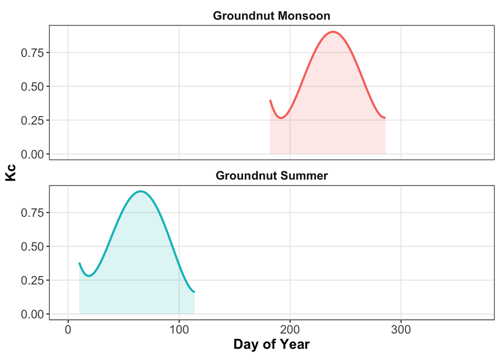

Continuous polynomial curves modeling the rapid growth dynamics of groundnuts.

```r
poly_list <- base::list()

# Only generate the curve if the user included this crop in their data!
if ("Groundnut Summer" %in% crop.param$crop) {
  poly_list[[1]] <- base::data.frame(doy = 1:366) %>%
    dplyr::mutate(crop = "Groundnut Summer", d = doy - 10,
           kc = dplyr::if_else(d >= 0 & d <= 104, 1.25*10^(-7)*d^4 - 2.82*10^(-5)*d^3 + 1.8*10^(-3)*d^2 - 2.49*10^(-2)*d + 0.3792, 0))
}

if ("Groundnut Monsoon" %in% crop.param$crop) {
  poly_list[[2]] <- base::data.frame(doy = 1:366) %>%
    dplyr::mutate(crop = "Groundnut Monsoon", d = doy - 182,
           kc = dplyr::if_else(d >= 0 & d <= 104, 1.32*10^(-7)*d^4 - 2.99*10^(-5)*d^3 + 1.96*10^(-3)*d^2 - 3.02*10^(-2)*d + 0.4, 0))
}

# Bind gracefully (will return an empty tibble if neither crop exists, preventing crashes)
kc_polynomial <- dplyr::bind_rows(poly_list)
if(base::nrow(kc_polynomial) > 0) kc_polynomial <- kc_polynomial %>% dplyr::select(-d)

# Visual Check
if(base::nrow(kc_polynomial) > 0) {
  poly_fig <- ggplot2::ggplot(kc_polynomial %>% dplyr::mutate(plot_kc = dplyr::if_else(kc == 0, NA_real_, kc)),
         ggplot2::aes(x = doy, y = plot_kc, color = crop)) +
    ggplot2::geom_area(ggplot2::aes(fill = crop), alpha = 0.15, show.legend = FALSE) +
    ggplot2::geom_line(linewidth = 1, na.rm = TRUE) +
    ggplot2::facet_wrap(. ~ crop, ncol = 1) +
    theme_baseR +
    ggplot2::labs(x = "Day of Year", y = "Kc")
  base::print(poly_fig)
}
```

### 4.2.3 Fruit Trees

Processes perennial step-functions for orchard crops.

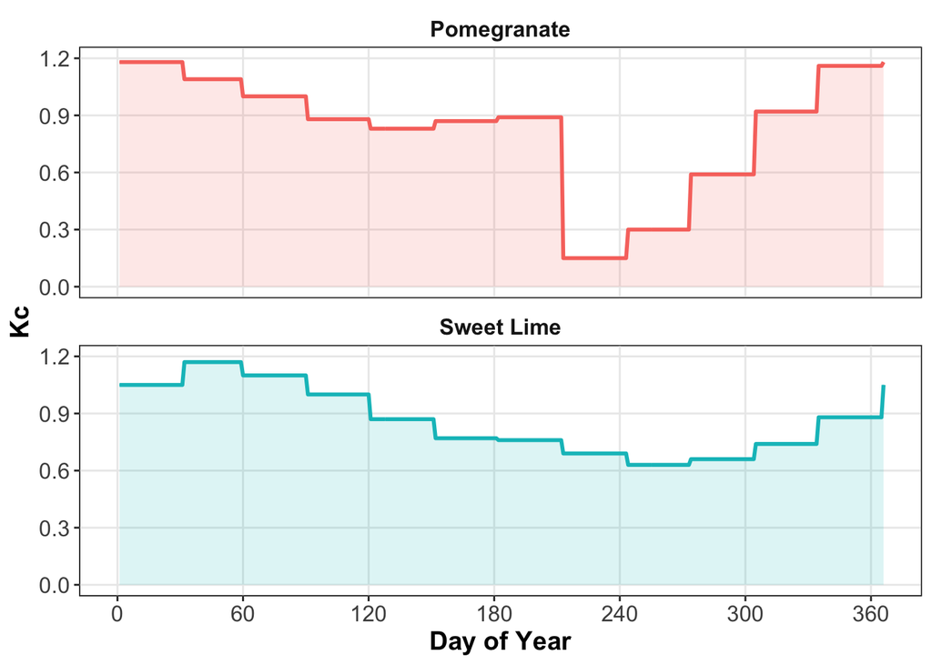

Monthly step-function curves for specific orchard crops. Note that this does not include all fruit trees; some (such as banana) are modeled using the standard FAO segmented curves.

```r
base::colnames(fruit_kc_raw) <- stringr::str_to_title(base::gsub("_|\\.", " ", base::colnames(fruit_kc_raw)))
kc_fruits <- dplyr::bind_rows(
  generate_fruit_step("Pomegranate", fruit_kc_raw),
  generate_fruit_step("Sweet Lime", fruit_kc_raw)
)

# Visual Check
ggplot2::ggplot(kc_fruits %>% dplyr::mutate(plot_kc = dplyr::if_else(kc == 0, NA_real_, kc)), ggplot2::aes(x = doy, y = plot_kc, color = crop)) +
  ggplot2::geom_area(ggplot2::aes(fill = crop), alpha = 0.15, show.legend = FALSE) +
  ggplot2::geom_line(linewidth = 1, na.rm = TRUE) +
  ggplot2::facet_wrap(. ~ crop, ncol = 1) +
  theme_baseR +
  ggplot2::labs(x = "Day of Year", y = "Kc") +
  ggplot2::scale_x_continuous(breaks = seq(0, 366, 60), limits = c(0, 366)) +
  ggplot2::scale_y_continuous(breaks = seq(0, 1.2, 0.3), limits = c(0, 1.2))
```

### 4.2.4 Grasslands and Fodder Crops

Applies calibrated drop-and-regrowth rates for grazed pastures and harvested Napier grass.

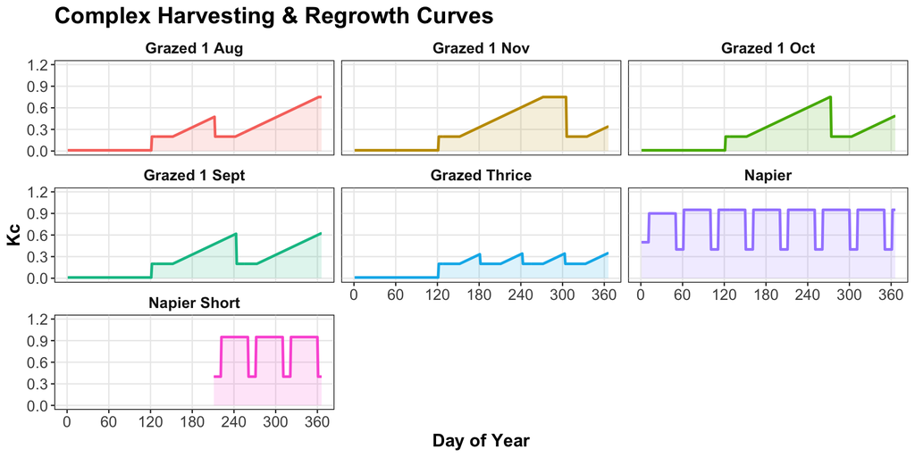

Complex harvesting and regrowth schedules illustrating calibrated drop-and-regrowth rates for grazed pastures and Napier grass.

```r
no_crop <- tibble::tibble(doy = 1:366, crop = "No Crop", kc = 0)

# Safely extract grassland baseline if it exists in the user's crop list
grassland_sow <- if("Grasslands" %in% kc_wide_build$crop) kc_wide_build$Sow[kc_wide_build$crop == "Grasslands"] else NA
grassland_base <- if("Grasslands" %in% kc_segmented$crop) kc_segmented %>% dplyr::filter(crop == "Grasslands") %>% dplyr::pull(kc) else base::rep(0, 366)

# ============================================================
# GRASSLAND GROWTH CYCLE PARAMETERS
# ============================================================

grazing_growth_rate   <- 0.00458333333333333
grazing_drop_kc       <- 0.20
grazing_max_kc        <- 0.75
napier_decline_rate_1 <- 0.000307692307692308
napier_decline_rate_2 <- 0.000153846153846154


# 1. Define the unique variables in clean, readable lists
grazing_schedules <- list(
  "Grazed Thrice" = c(182, 243, 304),
  "Grazed 1 Aug"  = 213,
  "Grazed 1 Sept" = 244,
  "Grazed 1 Oct"  = 274,
  "Grazed 1 Nov"  = 306
)

napier_schedules <- base::list(
  "Napier"       = 1,
  "Napier Short" = 211
)

# 2. Iterate through them efficiently
complex_list <- base::list()

for (c_name in base::names(grazing_schedules)) {
  if (c_name %in% crop.param$crop) {
    complex_list[[c_name]] <- generate_grazed_legacy(c_name, grazing_schedules[[c_name]], grassland_base, grazing_growth_rate, grazing_drop_kc, grazing_max_kc, grassland_sow)
  }
}

for (c_name in base::names(napier_schedules)) {
  if (c_name %in% crop.param$crop) {
    complex_list[[c_name]] <- generate_napier(c_name, napier_schedules[[c_name]], napier_decline_rate_1, napier_decline_rate_2)
  }
}

# Bind gracefully
complex_plot_data <- dplyr::bind_rows(complex_list)

# Visual Check (Only plot if there is actually complex data to show)
if (base::nrow(complex_plot_data) > 0) {
  complex_fig <- ggplot2::ggplot(complex_plot_data %>% dplyr::mutate(plot_kc = dplyr::if_else(kc == 0, NA_real_, kc)), ggplot2::aes(x = doy, y = plot_kc, color = crop)) +
    ggplot2::geom_area(ggplot2::aes(fill = crop), alpha = 0.15, show.legend = FALSE) +
    ggplot2::geom_line(linewidth = 1, na.rm = TRUE) +
    ggplot2::facet_wrap(~ crop) +
    theme_baseR +
    ggplot2::labs(title = "Complex Harvesting & Regrowth Curves", x = "Day of Year", y = "Kc") +
  ggplot2::scale_x_continuous(breaks = seq(0, 366, 60), limits = c(0, 366)) +
  ggplot2::scale_y_continuous(breaks = seq(0, 1.2, 0.3), limits = c(0, 1.2))
  base::print(complex_fig)
}
```

#### 4.2.4.1 Kc Curve compilation for all crops

Compile all generated Kc curves.

```r
# bind_rows handles empty dataframes perfectly, so we can safely bind everything
kc.doy.crop.all <- dplyr::bind_rows(
  kc_segmented,
  kc_polynomial,
  kc_fruits,
  no_crop,
  complex_plot_data
) %>% dplyr::arrange(crop, doy)

readr::write_csv(kc.doy.crop.all, file = here::here("data/processed/supplementary/01_crop_kc_by_doy_all_crops.csv"))
```

# 5 Cropping Systems

Read the file that describes the composition of each cropping system in terms of crop rotations at the plot scale.

```r
crop.systems <- data.table::fread(here::here("data/input/08_crop.systems.csv")) %>% dplyr::as_tibble()

knitr::kable(crop.systems, caption = "Cropping Systems")
```

Cropping Systems

| crop.system | Irrigation | n.rotation | rotation | soil | crop_1 | crop_2 | crop_3 |
| --- | --- | --- | --- | --- | --- | --- | --- |
| Finger Millet/Rice | Irrigated | 1 | Ragi Rice | 2 | Ragi | Rice Long | No Crop |
| Millets/Fallow | Rainfed | 1 | Millet | 1 | Millet | No Crop | No Crop |
| Pulses/Fallow | Rainfed | 1 | Pulse | 1 | Pulse | No Crop | No Crop |
| Grasslands (Grazed Once) | Rainfed | 1 | Grazed 1 Aug | 1 | Grazed 1 Aug | No Crop | No Crop |
| Grasslands (Grazed Once) | Rainfed | 1 | Grazed 1 Sept | 1 | Grazed 1 Sept | No Crop | No Crop |
| Grasslands (Grazed Once) | Rainfed | 1 | Grazed 1 Oct | 1 | Grazed 1 Oct | No Crop | No Crop |
| Grasslands (Grazed Once) | Rainfed | 1 | Grazed 1 Nov | 1 | Grazed 1 Nov | No Crop | No Crop |
| Grasslands | Rainfed | 1 | Grasslands | 1 | Grasslands | No Crop | No Crop |
| Groundnut/Fallow | Rainfed | 1 | Groundnut Monsoon | 1 | Groundnut Monsoon | No Crop | No Crop |
| Rice/Banana | Irrigated | 1 | Rice Banana 1 | 1 | Rice Short Summer | Banana 1 Beg | No Crop |
| Rice/Banana | Irrigated | 2 | Banana 1 | 1 | Banana 1 Next | No Crop | No Crop |
| Rice/Banana | Irrigated | 3 | Banana 2 | 1 | Banana 2 | No Crop | No Crop |
| Grapes | Irrigated | 1 | Grapes | 1 | Grapes | No Crop | No Crop |
| Pomegranate | Irrigated | 1 | Pomegranate | 1 | Pomegranate | No Crop | No Crop |
| Sweet Lime | Irrigated | 1 | Sweet Lime | 1 | Sweet Lime | No Crop | No Crop |
| Rice/Napier | Irrigated | 1 | Rice Napier | 2 | Rice Short Summer | Napier Short | No Crop |
| Rice/Napier | Irrigated | 2 | Napier | 2 | Napier | No Crop | No Crop |
| Rice/Fallow | Irrigated | 1 | Rice Fallow | 2 | Rice Short Monsoon | No Crop | No Crop |
| Horsegram (Grazed) | Rainfed | 1 | Horsegram | 1 | Horsegram | No Crop | No Crop |
| Grasslands (Grazed 3 Times) | Rainfed | 1 | Grazed Thrice | 1 | Grazed Thrice | No Crop | No Crop |
| Groundnut/Tomato/Tomato/Fallow | Irrigated | 1 | Tomato Groundnut | 1 | Groundnut Monsoon | Tomato Summer | No Crop |
| Groundnut/Tomato/Tomato/Fallow | Irrigated | 2 | Tomato Fallow | 1 | Tomato Winter | No Crop | No Crop |
| Groundnut/Okra/Okra/Fallow | Irrigated | 1 | Okra Groundnut | 1 | Groundnut Monsoon | Okra Summer | No Crop |
| Groundnut/Okra/Okra/Fallow | Irrigated | 2 | Okra Fallow | 1 | Okra Winter | No Crop | No Crop |

```r
preview_cs <- crop.systems
cs_cols <- base::colnames(preview_cs)

# Dynamically format column names to handle varying numbers of crop_X columns
new_cols <- base::sapply(cs_cols, function(col) {
  if (col == "rotation") {
    "rotation<br><small style='color:gray; font-weight:normal;'>Rotation ID/Code</small>"
  } else if (col == "n.rotation") {
    "n.rotation<br><small style='color:gray; font-weight:normal;'>Rotation Year (1, 2, etc.)</small>"
  } else if (col == "crop.system") {
    "crop.system<br><small style='color:gray; font-weight:normal;'>Descriptive system name</small>"
  } else if (col == "Irrigation") {
    "Irrigation<br><small style='color:gray; font-weight:normal;'>System-level irrigation status</small>"
  } else if (col == "soil") {
    "soil<br><small style='color:gray; font-weight:normal;'>Soil type code</small>"
  } else if (base::grepl("^crop_", col)) {
    base::paste0(col, "<br><small style='color:gray; font-weight:normal;'>Internal name for a crop or Crop-Year</small>")
  } else {
    col
  }
})

base::colnames(preview_cs) <- new_cols
knitr::kable(preview_cs, escape = FALSE, caption = "Preview: Cropping Systems")
```

Preview: Cropping Systems

| crop.system Descriptive system name | Irrigation System-level irrigation status | n.rotation Rotation Year (1, 2, etc.) | rotation Rotation ID/Code | soil Soil type code | crop_1 Internal name for a crop or Crop-Year | crop_2 Internal name for a crop or Crop-Year | crop_3 Internal name for a crop or Crop-Year |
| --- | --- | --- | --- | --- | --- | --- | --- |
| Finger Millet/Rice | Irrigated | 1 | Ragi Rice | 2 | Ragi | Rice Long | No Crop |
| Millets/Fallow | Rainfed | 1 | Millet | 1 | Millet | No Crop | No Crop |
| Pulses/Fallow | Rainfed | 1 | Pulse | 1 | Pulse | No Crop | No Crop |
| Grasslands (Grazed Once) | Rainfed | 1 | Grazed 1 Aug | 1 | Grazed 1 Aug | No Crop | No Crop |
| Grasslands (Grazed Once) | Rainfed | 1 | Grazed 1 Sept | 1 | Grazed 1 Sept | No Crop | No Crop |
| Grasslands (Grazed Once) | Rainfed | 1 | Grazed 1 Oct | 1 | Grazed 1 Oct | No Crop | No Crop |
| Grasslands (Grazed Once) | Rainfed | 1 | Grazed 1 Nov | 1 | Grazed 1 Nov | No Crop | No Crop |
| Grasslands | Rainfed | 1 | Grasslands | 1 | Grasslands | No Crop | No Crop |
| Groundnut/Fallow | Rainfed | 1 | Groundnut Monsoon | 1 | Groundnut Monsoon | No Crop | No Crop |
| Rice/Banana | Irrigated | 1 | Rice Banana 1 | 1 | Rice Short Summer | Banana 1 Beg | No Crop |
| Rice/Banana | Irrigated | 2 | Banana 1 | 1 | Banana 1 Next | No Crop | No Crop |
| Rice/Banana | Irrigated | 3 | Banana 2 | 1 | Banana 2 | No Crop | No Crop |
| Grapes | Irrigated | 1 | Grapes | 1 | Grapes | No Crop | No Crop |
| Pomegranate | Irrigated | 1 | Pomegranate | 1 | Pomegranate | No Crop | No Crop |
| Sweet Lime | Irrigated | 1 | Sweet Lime | 1 | Sweet Lime | No Crop | No Crop |
| Rice/Napier | Irrigated | 1 | Rice Napier | 2 | Rice Short Summer | Napier Short | No Crop |
| Rice/Napier | Irrigated | 2 | Napier | 2 | Napier | No Crop | No Crop |
| Rice/Fallow | Irrigated | 1 | Rice Fallow | 2 | Rice Short Monsoon | No Crop | No Crop |
| Horsegram (Grazed) | Rainfed | 1 | Horsegram | 1 | Horsegram | No Crop | No Crop |
| Grasslands (Grazed 3 Times) | Rainfed | 1 | Grazed Thrice | 1 | Grazed Thrice | No Crop | No Crop |
| Groundnut/Tomato/Tomato/Fallow | Irrigated | 1 | Tomato Groundnut | 1 | Groundnut Monsoon | Tomato Summer | No Crop |
| Groundnut/Tomato/Tomato/Fallow | Irrigated | 2 | Tomato Fallow | 1 | Tomato Winter | No Crop | No Crop |
| Groundnut/Okra/Okra/Fallow | Irrigated | 1 | Okra Groundnut | 1 | Groundnut Monsoon | Okra Summer | No Crop |
| Groundnut/Okra/Okra/Fallow | Irrigated | 2 | Okra Fallow | 1 | Okra Winter | No Crop | No Crop |

## 5.1 Build annual/multi-annual cropping systems/rotations by compiling individual Crop Kc Curves.

```r
# Generate the long-format rotation table
crop.systems.l <- crop.systems %>%
  dplyr::select(-Irrigation) %>%
  tidyr::pivot_longer(cols = dplyr::starts_with("crop_"), names_prefix = "crop_", names_to = "ncrop", values_to = "crop") %>%
  dplyr::left_join(crop.param, by = "crop")

crop.systems.l.kc <- crop.systems.l %>%
  dplyr::select(rotation, n.rotation, crop.system, soil, ncrop, crop, irrigation, rooting_depth_cm) %>%
  dplyr::left_join(kc.doy.crop.all %>% dplyr::arrange(doy, crop), by = "crop", relationship = "many-to-many")
```

### 5.1.1 Daily Kc Table by Crop Rotation

*(Example showing the generated continuous timeline for a single rotation).*

Preview: Daily Kc Table (Single Rotation)

| crop.system Rotation Name | crop Active Crop | doy Day of Year (1-366) | kc Daily Crop Coefficient |
| --- | --- | --- | --- |
| Rice/Banana | Banana 1 Next | 1 | 1 |
| Rice/Banana | Banana 1 Next | 2 | 1 |
| Rice/Banana | Banana 1 Next | 3 | 1 |
| Rice/Banana | Banana 1 Next | 4 | 1 |
| Rice/Banana | Banana 1 Next | 5 | 1 |
| Rice/Banana | Banana 1 Next | 6 | 1 |
| Rice/Banana | Banana 1 Next | 7 | 1 |
| Rice/Banana | Banana 1 Next | 8 | 1 |
| Rice/Banana | Banana 1 Next | 9 | 1 |
| Rice/Banana | Banana 1 Next | 10 | 1 |

# 6 Production Systems

Read the file that describes the composition of each production system in terms of cropping systems and their area. For the case study in Hemingway et al. (2026), this information is taken from Tables 1 & 2 of Hemingway et al. (2025) and modified in Hemingway et al. (2026a).

```r
ps_by_cs_area  <- data.table::fread(here::here("data/input/09_crop_system_area_by_production_system.csv")) %>% dplyr::as_tibble()
```

Crop Area under each Production System

| time_period Historical grouping | report_group_name Broader Agrarian Group | production_system Agrarian Group | sub-production_system Agrarian Sub-Group | crop.system Implemented rotation | land_use_type Land Use Type | area_ha Cultivated area **Expected:** Numeric |
| --- | --- | --- | --- | --- | --- | --- |
| 1950 | Large landholders | Large landholders | Large landholders | Finger Millet/Rice | Irrigated | 1.21 |
| 1950 | Large landholders | Large landholders | Large landholders | Grasslands | Grasslands | 0.67 |
| 1950 | Large landholders | Large landholders | Large landholders | Grasslands (Grazed Once) | Grazed | 14.20 |
| 1950 | Large landholders | Large landholders | Large landholders | Groundnut/Fallow | Rainfed | 3.60 |
| 1950 | Large landholders | Large landholders | Large landholders | Millets/Fallow | Rainfed | 1.80 |
| 1950 | Large landholders | Large landholders | Large landholders | Pulses/Fallow | Rainfed | 2.13 |
| 1950 | Smallholders | Smallholders | Smallholders | Finger Millet/Rice | Irrigated | 0.40 |
| 1950 | Smallholders | Smallholders | Smallholders | Grasslands | Grasslands | 0.27 |
| 1950 | Smallholders | Smallholders | Smallholders | Grasslands (Grazed Once) | Grazed | 5.76 |
| 1950 | Smallholders | Smallholders | Smallholders | Millets/Fallow | Rainfed | 1.20 |
| 1950 | Smallholders | Smallholders | Smallholders | Pulses/Fallow | Rainfed | 0.40 |
| 1950 | Pastoralists | Pastoralists | Pastoralists | Grasslands | Grasslands | 0.67 |
| 1950 | Pastoralists | Pastoralists | Pastoralists | Grasslands (Grazed Once) | Grazed | 14.15 |
| 1950 | Landless households | Landless households | Landless | Groundnut/Fallow | Rainfed | 0.00 |
| 2022 | Vegetable growers (with or without dairy farming) | Vegetable growers_dairy farming | Vegetable growers (dairy farming) | Groundnut/Tomato/Tomato/Fallow | Irrigated | 1.95 |
| 2022 | Vegetable growers (with or without dairy farming) | Vegetable growers_dairy farming | Vegetable growers (dairy farming) | Rice/Napier | Irrigated | 0.08 |
| 2022 | Vegetable growers (with or without dairy farming) | Vegetable growers_no livestock | Vegetable growers (no livestock) | Groundnut/Okra/Okra/Fallow | Irrigated | 2.02 |
| 2022 | Small-scale fruit growers (+ dairy farming) | Small-scale fruit growers | Small-scale fruit growers (sweet lime) | Groundnut/Fallow | Rainfed | 1.16 |
| 2022 | Small-scale fruit growers (+ dairy farming) | Small-scale fruit growers | Small-scale fruit growers (sweet lime) | Rice/Napier | Irrigated | 0.08 |
| 2022 | Small-scale fruit growers (+ dairy farming) | Small-scale fruit growers | Small-scale fruit growers (sweet lime) | Sweet Lime | Irrigated | 0.79 |
| 2022 | Small-scale fruit growers (+ dairy farming) | Small-scale fruit growers | Small-scale fruit growers (grape vines) | Grapes | Irrigated | 0.79 |
| 2022 | Small-scale fruit growers (+ dairy farming) | Small-scale fruit growers | Small-scale fruit growers (grape vines) | Groundnut/Fallow | Rainfed | 1.16 |
| 2022 | Small-scale fruit growers (+ dairy farming) | Small-scale fruit growers | Small-scale fruit growers (grape vines) | Rice/Napier | Irrigated | 0.08 |
| 2022 | Small-scale fruit growers (+ dairy farming) | Small-scale fruit growers | Small-scale fruit growers (pomegranate) | Groundnut/Fallow | Rainfed | 1.16 |
| 2022 | Small-scale fruit growers (+ dairy farming) | Small-scale fruit growers | Small-scale fruit growers (pomegranate) | Pomegranate | Irrigated | 0.79 |
| 2022 | Small-scale fruit growers (+ dairy farming) | Small-scale fruit growers | Small-scale fruit growers (pomegranate) | Rice/Napier | Irrigated | 0.08 |
| 2022 | Small-scale fruit growers (+ dairy farming) | Small-scale fruit growers | Small-scale fruit growers (banana) | Groundnut/Fallow | Rainfed | 1.16 |
| 2022 | Small-scale fruit growers (+ dairy farming) | Small-scale fruit growers | Small-scale fruit growers (banana) | Rice/Banana | Irrigated | 0.79 |
| 2022 | Small-scale fruit growers (+ dairy farming) | Small-scale fruit growers | Small-scale fruit growers (banana) | Rice/Napier | Irrigated | 0.08 |
| 2022 | Rice growers (no livestock) | Rice growers | Rice growers | Groundnut/Fallow | Rainfed | 1.29 |
| 2022 | Rice growers (no livestock) | Rice growers | Rice growers | Rice/Fallow | Irrigated | 0.74 |
| 2022 | Large-scale fruit growers | Large-scale fruit growers | Large-scale fruit growers | Grapes | Irrigated | 2.02 |
| 2022 | Large-scale fruit growers | Large-scale fruit growers | Large-scale fruit growers | Pomegranate | Irrigated | 4.05 |
| 2022 | Pastoralists | Pastoralists | Pastoralists | Grasslands (Grazed 3 Times) | Grazed | 13.17 |
| 2022 | Pastoralists | Pastoralists | Pastoralists | Horsegram (Grazed) | Rainfed | 2.02 |
| 2022 | Groundnut growers (with livestock) | Rainfed groundnut growers_bulls | Rainfed groundnut growers (bulls) | Grasslands (Grazed 3 Times) | Grazed | 0.29 |
| 2022 | Groundnut growers (with livestock) | Rainfed groundnut growers_bulls | Rainfed groundnut growers (bulls) | Groundnut/Fallow | Rainfed | 2.02 |
| 2022 | Groundnut growers (with livestock) | Rainfed groundnut growers_bulls | Rainfed groundnut growers (bulls) | Rice/Fallow (Red Soils) | Irrigated | 0.26 |
| 2022 | Groundnut growers (with livestock) | Rainfed groundnut growers_with other livestock | Sheep fatteners | Grasslands (Grazed 3 Times) | Grazed | 0.16 |
| 2022 | Groundnut growers (with livestock) | Rainfed groundnut growers_with other livestock | Sheep fatteners | Groundnut/Fallow | Rainfed | 2.02 |
| 2022 | Groundnut growers (with livestock) | Rainfed groundnut growers_with other livestock | Rainfed groundnut growers (buffaloes) | Grasslands (Grazed 3 Times) | Grazed | 0.73 |
| 2022 | Groundnut growers (with livestock) | Rainfed groundnut growers_with other livestock | Rainfed groundnut growers (buffaloes) | Groundnut/Fallow | Rainfed | 2.02 |
| 2022 | Groundnut growers (with livestock) | Rainfed groundnut growers_with other livestock | Rainfed groundnut growers (cows) | Grasslands (Grazed 3 Times) | Grazed | 0.75 |
| 2022 | Groundnut growers (with livestock) | Rainfed groundnut growers_with other livestock | Rainfed groundnut growers (cows) | Groundnut/Fallow | Rainfed | 2.02 |
| 2022 | Groundnut growers (no livestock) | Rainfed groundnut or redgram growers_no livestock | Rainfed groundnut growers (no livestock) | Groundnut/Fallow | Rainfed | 2.02 |
| 2022 | Groundnut growers (no livestock) | Rainfed groundnut or redgram growers_no livestock | Rainfed redgram growers (no livestock) | Pulses/Fallow | Rainfed | 2.02 |
| 2022 | Landless households | Landless households | Landless | Groundnut/Fallow | Rainfed | 0.00 |
| 2022 | Unused land | Unused land | unused land | Grasslands | Grasslands | 7.62 |

# 7 Agrarian System

Read the file with number of farms belonging to each of the Production Systems in the Agrarian System of the considered area (village, micro-region, watershed). In our case study these numbers are calculated for two periods using an optimisation technique as described in Hemingway et al. (2026a).

```r
farms_count_df <- data.table::fread(here::here("data/input/10_no_of_farmers_by_production_system.csv")) %>% dplyr::as_tibble()
```

Farm Counts Per Production System

| time_period Historical grouping | production_system Agrarian Group | sub_production_system Agrarian Sub-Group | number_of_farms Total farmer count **Expected:** Numeric |
| --- | --- | --- | --- |
| 1950 | Large landholders | Large landholders | 8 |
| 1950 | Smallholders | Smallholders | 80 |
| 1950 | Pastoralists | Pastoralists | 8 |
| 1950 | Landless households | Landless | 64 |
| 2022 | Vegetable growers_dairy farming | Vegetable growers (dairy farming) | 21 |
| 2022 | Vegetable growers_no livestock | Vegetable growers (no livestock) | 20 |
| 2022 | Small-scale fruit growers | Small-scale fruit growers (sweet lime) | 21 |
| 2022 | Small-scale fruit growers | Small-scale fruit growers (grape vines) | 7 |
| 2022 | Small-scale fruit growers | Small-scale fruit growers (pomegranate) | 7 |
| 2022 | Small-scale fruit growers | Small-scale fruit growers (banana) | 7 |
| 2022 | Rice growers | Rice growers | 23 |
| 2022 | Large-scale fruit growers | Large-scale fruit growers | 2 |
| 2022 | Pastoralists | Pastoralists | 18 |
| 2022 | Rainfed groundnut growers_bulls | Rainfed groundnut growers (bulls) | 4 |
| 2022 | Rainfed groundnut growers_with other livestock | Sheep fatteners | 11 |
| 2022 | Rainfed groundnut growers_with other livestock | Rainfed groundnut growers (buffaloes) | 11 |
| 2022 | Rainfed groundnut growers_with other livestock | Rainfed groundnut growers (cows) | 12 |
| 2022 | Rainfed groundnut or redgram growers_no livestock | Rainfed groundnut growers (no livestock) | 128 |
| 2022 | Rainfed groundnut or redgram growers_no livestock | Rainfed redgram growers (no livestock) | 42 |
| 2022 | Landless households | Landless | 6 |
| 2022 | Unused land | unused land | 1 |

# 8 References

Allen, R.G., Pereira, L.S., Raes, D., Smith, M., 1998. Crop evapotranspiration-Guidelines for computing crop water requirements-FAO Irrigation and drainage paper 56. FAO - Food and Agriculture Organization of the United Nations, Rome, Italy.

Hemingway C., Ruiz L., Vigne M., Aubron C., 2025. The changing role of livestock in agrarian systems: a historical and multifunctional perspective from southern India. Agronomy for Sustainable Development. 45(1): 7. https://doi.org/10.1007/s13593-024-00999-9

Hemingway, C., Aubron, C., Chitra-Tarak, R., Boulet, G., Vigne, M., Muddu, S., & Ruiz, L. (2026a). Archetype Village Generator: an R framework for developing modelled representations of agricultural regions under farm-level data scarcity (application to the Anantapur agrarian system, India, 1950s–2022) (Version v1.0.0) [Computer software]. Zenodo. https://doi.org/10.5281/zenodo.21806589

# 9 Preferred Citation

If you use this toolkit, its underlying logic, or adapt the framework for another study, please cite both the software repository and the primary manuscript:

- **Software:** Chitra-Tarak, R., Hemingway, C., Aubron, C., Boulet, G., Vigne, M., Sekhar M. & Ruiz, L. (2026). The Blue Water Potential Toolkit: a socio-hydrological framework to scale water budgets from plot to agrarian system (Version 1.0.0) [Computer software]. Zenodo. https://doi.org/10.5281/zenodo.20665272
- **Article:** Hemingway, C., Aubron, C., Chitra-Tarak, R., Boulet, G., Vigne, M., Sekhar M., & Ruiz, L. (2026). Accounting the unaccounted: a new framework for incorporating farm social diversity in micro-regional water budgets. Journal of Hydrology. 681, 136621. https://doi.org/10.1016/j.jhydrol.2026.136621